# Risk Factor Analysis

## Outcome Variable

**Outcome Variable:** whz

## Predictor Variables

**Intervention Variable:** earlybf

**Adjustment Set:**

- arm
- sex
- W_mage
- meducyrs
- feducyrs
- hhwealth_quart
- hfoodsec
- W_mhtcm
- W_mwtkg
- W_mbmi
- vagbrth
- W_gagebrth
- W_birthwt
- W_birthlen
- W_nrooms
- W_nchldlt5
- brthmon
- W_parity
- impfloor
- impsan
- safeh20
- delta_W_mage
- delta_meducyrs
- delta_feducyrs
- delta_hhwealth_quart
- delta_hfoodsec
- delta_W_mhtcm
- delta_W_mwtkg
- delta_W_mbmi
- delta_vagbrth
- delta_W_gagebrth
- delta_W_birthwt
- delta_W_birthlen
- delta_W_nrooms
- delta_W_nchldlt5
- delta_brthmon
- delta_W_parity
- delta_impfloor
- delta_impsan
- delta_safeh20

## Stratifying Variables

The analysis was stratified on these variable(s):

- agecat
- studyid
- country

## Data Summary

| agecat | studyid | country | earlybf | n_cell | n | outcome_variable |
| --- | --- | --- | --- | --- | --- | --- |
| Birth | ki0047075b-MAL-ED | BANGLADESH | 1 | 140 | 214 | whz |
| Birth | ki0047075b-MAL-ED | BANGLADESH | 0 | 74 | 214 | whz |
| Birth | ki0047075b-MAL-ED | BRAZIL | 1 | 26 | 62 | whz |
| Birth | ki0047075b-MAL-ED | BRAZIL | 0 | 36 | 62 | whz |
| Birth | ki0047075b-MAL-ED | INDIA | 1 | 31 | 44 | whz |
| Birth | ki0047075b-MAL-ED | INDIA | 0 | 13 | 44 | whz |
| Birth | ki0047075b-MAL-ED | NEPAL | 1 | 14 | 26 | whz |
| Birth | ki0047075b-MAL-ED | NEPAL | 0 | 12 | 26 | whz |
| Birth | ki0047075b-MAL-ED | PERU | 1 | 172 | 228 | whz |
| Birth | ki0047075b-MAL-ED | PERU | 0 | 56 | 228 | whz |
| Birth | ki0047075b-MAL-ED | SOUTH AFRICA | 1 | 69 | 110 | whz |
| Birth | ki0047075b-MAL-ED | SOUTH AFRICA | 0 | 41 | 110 | whz |
| Birth | ki0047075b-MAL-ED | TANZANIA, UNITED REPUBLIC OF | 1 | 103 | 115 | whz |
| Birth | ki0047075b-MAL-ED | TANZANIA, UNITED REPUBLIC OF | 0 | 12 | 115 | whz |
| Birth | ki1000109-EE | PAKISTAN | 1 | 36 | 170 | whz |
| Birth | ki1000109-EE | PAKISTAN | 0 | 134 | 170 | whz |
| Birth | ki1000304b-SAS-CompFeed | INDIA | 1 | 79 | 1072 | whz |
| Birth | ki1000304b-SAS-CompFeed | INDIA | 0 | 993 | 1072 | whz |
| Birth | ki1017093c-NIH-Crypto | BANGLADESH | 1 | 613 | 707 | whz |
| Birth | ki1017093c-NIH-Crypto | BANGLADESH | 0 | 94 | 707 | whz |
| Birth | ki1113344-GMS-Nepal | NEPAL | 1 | 171 | 586 | whz |
| Birth | ki1113344-GMS-Nepal | NEPAL | 0 | 415 | 586 | whz |
| Birth | ki1126311-ZVITAMBO | ZIMBABWE | 1 | 6142 | 11514 | whz |
| Birth | ki1126311-ZVITAMBO | ZIMBABWE | 0 | 5372 | 11514 | whz |
| Birth | kiGH5241-JiVitA-3 | BANGLADESH | 1 | 105 | 17943 | whz |
| Birth | kiGH5241-JiVitA-3 | BANGLADESH | 0 | 17838 | 17943 | whz |
| Birth | kiGH5241-JiVitA-4 | BANGLADESH | 1 | 1624 | 2396 | whz |
| Birth | kiGH5241-JiVitA-4 | BANGLADESH | 0 | 772 | 2396 | whz |
| 6 months | ki0047075b-MAL-ED | BANGLADESH | 1 | 147 | 240 | whz |
| 6 months | ki0047075b-MAL-ED | BANGLADESH | 0 | 93 | 240 | whz |

[output cut: 52 more lines]

The following strata were considered:

- agecat: 24 months, studyid: ki0047075b-MAL-ED, country: BANGLADESH
- agecat: 24 months, studyid: ki0047075b-MAL-ED, country: BRAZIL
- agecat: 24 months, studyid: ki0047075b-MAL-ED, country: INDIA
- agecat: 24 months, studyid: ki0047075b-MAL-ED, country: NEPAL
- agecat: 24 months, studyid: ki0047075b-MAL-ED, country: PERU
- agecat: 24 months, studyid: ki0047075b-MAL-ED, country: SOUTH AFRICA
- agecat: 24 months, studyid: ki0047075b-MAL-ED, country: TANZANIA, UNITED REPUBLIC OF
- agecat: 24 months, studyid: ki1000109-EE, country: PAKISTAN
- agecat: 24 months, studyid: ki1017093c-NIH-Crypto, country: BANGLADESH
- agecat: 24 months, studyid: ki1113344-GMS-Nepal, country: NEPAL
- agecat: 24 months, studyid: ki1126311-ZVITAMBO, country: ZIMBABWE
- agecat: 24 months, studyid: kiGH5241-JiVitA-3, country: BANGLADESH
- agecat: 24 months, studyid: kiGH5241-JiVitA-4, country: BANGLADESH
- agecat: 6 months, studyid: ki0047075b-MAL-ED, country: BANGLADESH
- agecat: 6 months, studyid: ki0047075b-MAL-ED, country: BRAZIL
- agecat: 6 months, studyid: ki0047075b-MAL-ED, country: INDIA
- agecat: 6 months, studyid: ki0047075b-MAL-ED, country: NEPAL
- agecat: 6 months, studyid: ki0047075b-MAL-ED, country: PERU
- agecat: 6 months, studyid: ki0047075b-MAL-ED, country: SOUTH AFRICA
- agecat: 6 months, studyid: ki0047075b-MAL-ED, country: TANZANIA, UNITED REPUBLIC OF
- agecat: 6 months, studyid: ki1000109-EE, country: PAKISTAN
- agecat: 6 months, studyid: ki1000304b-SAS-CompFeed, country: INDIA
- agecat: 6 months, studyid: ki1017093c-NIH-Crypto, country: BANGLADESH
- agecat: 6 months, studyid: ki1113344-GMS-Nepal, country: NEPAL
- agecat: 6 months, studyid: ki1126311-ZVITAMBO, country: ZIMBABWE
- agecat: 6 months, studyid: kiGH5241-JiVitA-3, country: BANGLADESH
- agecat: 6 months, studyid: kiGH5241-JiVitA-4, country: BANGLADESH
- agecat: Birth, studyid: ki0047075b-MAL-ED, country: BANGLADESH
- agecat: Birth, studyid: ki0047075b-MAL-ED, country: BRAZIL
- agecat: Birth, studyid: ki0047075b-MAL-ED, country: INDIA
- agecat: Birth, studyid: ki0047075b-MAL-ED, country: NEPAL
- agecat: Birth, studyid: ki0047075b-MAL-ED, country: PERU
- agecat: Birth, studyid: ki0047075b-MAL-ED, country: SOUTH AFRICA
- agecat: Birth, studyid: ki0047075b-MAL-ED, country: TANZANIA, UNITED REPUBLIC OF
- agecat: Birth, studyid: ki1000109-EE, country: PAKISTAN
- agecat: Birth, studyid: ki1000304b-SAS-CompFeed, country: INDIA
- agecat: Birth, studyid: ki1017093c-NIH-Crypto, country: BANGLADESH
- agecat: Birth, studyid: ki1113344-GMS-Nepal, country: NEPAL
- agecat: Birth, studyid: ki1126311-ZVITAMBO, country: ZIMBABWE
- agecat: Birth, studyid: kiGH5241-JiVitA-3, country: BANGLADESH
- agecat: Birth, studyid: kiGH5241-JiVitA-4, country: BANGLADESH

### Dropped Strata

Some strata were dropped due to rare outcomes:

- agecat: 24 months, studyid: kiGH5241-JiVitA-3, country: BANGLADESH

## Methods Detail

We’re interested in the causal parameters $E[Y_a]$ for all values of $a \in \mathcal{A}$. These parameters represent the mean outcome if, possibly contrary to fact, we intervened to set all units to have $A=a$. Under the randomization and positivity assumptions, these are identified by the statistical parameters $\psi_a=E_W[E_{Y|A,W}(Y|A=a,W)]$. In addition, we’re interested in the mean of $Y$, $E[Y]$ under no intervention (the observed mean). We will estimate these parameters by using SuperLearner to fit the relevant likelihood factors – $E_{Y|A,W}(Y|A=a,W)$ and $p(A=a|W)$, and then updating our likelihood fit using a joint TMLE.

For unadjusted analyses ($W=\{\}$), initial likelihoods were estimated using Lrnr_glm to estimate the simple $E(Y|A)$ and Lrnr_mean to estimate $p(A)$. For adjusted analyses, a small library containing Lrnr_glmnet, Lrnr_xgboost, and Lrnr_mean was used.

Having estimated these parameters, we will then use the delta method to estimate relative risks and attributable risks relative to a prespecified baseline level of $A$.

# Results Detail

## Results Plots

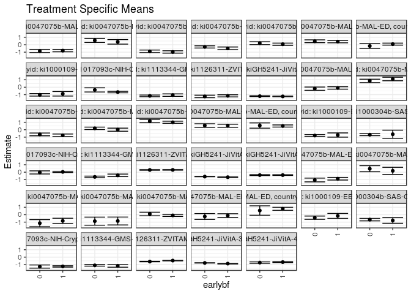

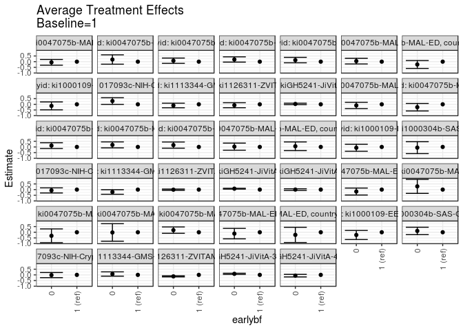

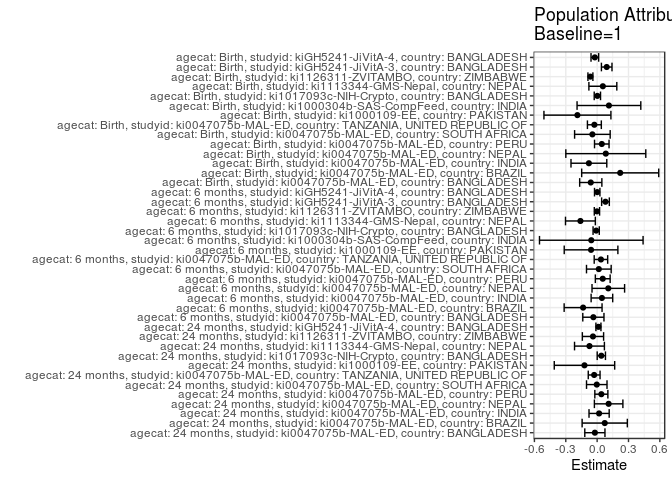

## Results Table

### Parameter: TSM

| agecat | studyid | country | intervention_level | baseline_level | estimate | ci_lower | ci_upper |
| --- | --- | --- | --- | --- | --- | --- | --- |
| Birth | ki0047075b-MAL-ED | BANGLADESH | 1 | NA | -0.8781510 | -1.0554289 | -0.7008730 |
| Birth | ki0047075b-MAL-ED | BANGLADESH | 0 | NA | -1.0499539 | -1.3029103 | -0.7969976 |
| Birth | ki0047075b-MAL-ED | BRAZIL | 1 | NA | 0.1822218 | -0.2937512 | 0.6581948 |
| Birth | ki0047075b-MAL-ED | BRAZIL | 0 | NA | 0.4672551 | 0.0599186 | 0.8745915 |
| Birth | ki0047075b-MAL-ED | INDIA | 1 | NA | -0.8333612 | -1.1889724 | -0.4777499 |
| Birth | ki0047075b-MAL-ED | INDIA | 0 | NA | -1.1464935 | -1.6302659 | -0.6627211 |
| Birth | ki0047075b-MAL-ED | NEPAL | 1 | NA | -0.8513887 | -1.3824759 | -0.3203016 |
| Birth | ki0047075b-MAL-ED | NEPAL | 0 | NA | -0.8713381 | -1.4142461 | -0.3284300 |
| Birth | ki0047075b-MAL-ED | PERU | 1 | NA | -0.0964972 | -0.2352529 | 0.0422584 |
| Birth | ki0047075b-MAL-ED | PERU | 0 | NA | 0.0894589 | -0.1528667 | 0.3317846 |
| Birth | ki0047075b-MAL-ED | SOUTH AFRICA | 1 | NA | -0.1235362 | -0.3774735 | 0.1304012 |
| Birth | ki0047075b-MAL-ED | SOUTH AFRICA | 0 | NA | -0.2439050 | -0.6400272 | 0.1522173 |
| Birth | ki0047075b-MAL-ED | TANZANIA, UNITED REPUBLIC OF | 1 | NA | 0.7888476 | 0.5860362 | 0.9916590 |
| Birth | ki0047075b-MAL-ED | TANZANIA, UNITED REPUBLIC OF | 0 | NA | 0.5556017 | -0.0788703 | 1.1900738 |
| Birth | ki1000109-EE | PAKISTAN | 1 | NA | -0.1636398 | -0.4949529 | 0.1676733 |
| Birth | ki1000109-EE | PAKISTAN | 0 | NA | -0.4061956 | -0.6278095 | -0.1845816 |
| Birth | ki1000304b-SAS-CompFeed | INDIA | 1 | NA | -0.7803988 | -1.1572587 | -0.4035389 |
| Birth | ki1000304b-SAS-CompFeed | INDIA | 0 | NA | -0.6662675 | -0.8343427 | -0.4981923 |
| Birth | ki1017093c-NIH-Crypto | BANGLADESH | 1 | NA | -1.2463946 | -1.3362383 | -1.1565510 |
| Birth | ki1017093c-NIH-Crypto | BANGLADESH | 0 | NA | -1.2650635 | -1.4772673 | -1.0528597 |
| Birth | ki1113344-GMS-Nepal | NEPAL | 1 | NA | -1.1807052 | -1.3500526 | -1.0113579 |
| Birth | ki1113344-GMS-Nepal | NEPAL | 0 | NA | -1.1037655 | -1.2067024 | -1.0008286 |
| Birth | ki1126311-ZVITAMBO | ZIMBABWE | 1 | NA | -0.4618852 | -0.4972573 | -0.4265131 |
| Birth | ki1126311-ZVITAMBO | ZIMBABWE | 0 | NA | -0.5937519 | -0.6316309 | -0.5558729 |
| Birth | kiGH5241-JiVitA-3 | BANGLADESH | 1 | NA | -0.8694261 | -0.9176503 | -0.8212020 |
| Birth | kiGH5241-JiVitA-3 | BANGLADESH | 0 | NA | -0.7773395 | -0.7968086 | -0.7578704 |
| Birth | kiGH5241-JiVitA-4 | BANGLADESH | 1 | NA | -0.6666073 | -0.7261535 | -0.6070611 |
| Birth | kiGH5241-JiVitA-4 | BANGLADESH | 0 | NA | -0.7338122 | -0.8323652 | -0.6352592 |
| 6 months | ki0047075b-MAL-ED | BANGLADESH | 1 | NA | -0.0956764 | -0.2569707 | 0.0656179 |
| 6 months | ki0047075b-MAL-ED | BANGLADESH | 0 | NA | -0.1956656 | -0.4180742 | 0.0267431 |
| 6 months | ki0047075b-MAL-ED | BRAZIL | 1 | NA | 1.1063761 | 0.8712438 | 1.3415084 |
| 6 months | ki0047075b-MAL-ED | BRAZIL | 0 | NA | 0.8501635 | 0.6193881 | 1.0809389 |
| 6 months | ki0047075b-MAL-ED | INDIA | 1 | NA | -0.7536596 | -0.9235281 | -0.5837911 |
| 6 months | ki0047075b-MAL-ED | INDIA | 0 | NA | -0.6340613 | -0.8221799 | -0.4459427 |
| 6 months | ki0047075b-MAL-ED | NEPAL | 1 | NA | 0.0035906 | -0.2041494 | 0.2113306 |
| 6 months | ki0047075b-MAL-ED | NEPAL | 0 | NA | 0.1848935 | 0.0200584 | 0.3497287 |
| 6 months | ki0047075b-MAL-ED | PERU | 1 | NA | 0.9992455 | 0.8574468 | 1.1410442 |
| 6 months | ki0047075b-MAL-ED | PERU | 0 | NA | 1.1632996 | 0.9336106 | 1.3929887 |
| 6 months | ki0047075b-MAL-ED | SOUTH AFRICA | 1 | NA | 0.5338122 | 0.3326265 | 0.7349979 |
| 6 months | ki0047075b-MAL-ED | SOUTH AFRICA | 0 | NA | 0.5596590 | 0.3176302 | 0.8016878 |
| 6 months | ki0047075b-MAL-ED | TANZANIA, UNITED REPUBLIC OF | 1 | NA | 0.4998645 | 0.3582055 | 0.6415235 |
| 6 months | ki0047075b-MAL-ED | TANZANIA, UNITED REPUBLIC OF | 0 | NA | 0.5613204 | 0.2093917 | 0.9132491 |
| 6 months | ki1000109-EE | PAKISTAN | 1 | NA | -0.7143599 | -0.9980926 | -0.4306271 |
| 6 months | ki1000109-EE | PAKISTAN | 0 | NA | -0.7862777 | -0.9126076 | -0.6599479 |
| 6 months | ki1000304b-SAS-CompFeed | INDIA | 1 | NA | -0.6097313 | -1.1597375 | -0.0597251 |
| 6 months | ki1000304b-SAS-CompFeed | INDIA | 0 | NA | -0.6712896 | -0.8039023 | -0.5386770 |
| 6 months | ki1017093c-NIH-Crypto | BANGLADESH | 1 | NA | 0.0389887 | -0.0462682 | 0.1242456 |
| 6 months | ki1017093c-NIH-Crypto | BANGLADESH | 0 | NA | -0.0324320 | -0.2408501 | 0.1759860 |
| 6 months | ki1113344-GMS-Nepal | NEPAL | 1 | NA | -0.4244815 | -0.5962845 | -0.2526784 |
| 6 months | ki1113344-GMS-Nepal | NEPAL | 0 | NA | -0.6356090 | -0.7428204 | -0.5283975 |
| 6 months | ki1126311-ZVITAMBO | ZIMBABWE | 1 | NA | 0.3091690 | 0.2725566 | 0.3457814 |
| 6 months | ki1126311-ZVITAMBO | ZIMBABWE | 0 | NA | 0.3014029 | 0.2606133 | 0.3421925 |
| 6 months | kiGH5241-JiVitA-3 | BANGLADESH | 1 | NA | -0.6733900 | -0.7047433 | -0.6420368 |
| 6 months | kiGH5241-JiVitA-3 | BANGLADESH | 0 | NA | -0.5933437 | -0.6133781 | -0.5733093 |
| 6 months | kiGH5241-JiVitA-4 | BANGLADESH | 1 | NA | -0.3905040 | -0.4351157 | -0.3458923 |
| 6 months | kiGH5241-JiVitA-4 | BANGLADESH | 0 | NA | -0.3896484 | -0.4505671 | -0.3287296 |
| 24 months | ki0047075b-MAL-ED | BANGLADESH | 1 | NA | -0.7924937 | -0.9491942 | -0.6357933 |
| 24 months | ki0047075b-MAL-ED | BANGLADESH | 0 | NA | -0.8516672 | -1.0529072 | -0.6504271 |
| 24 months | ki0047075b-MAL-ED | BRAZIL | 1 | NA | 0.3899250 | 0.0837275 | 0.6961224 |
| 24 months | ki0047075b-MAL-ED | BRAZIL | 0 | NA | 0.5793232 | 0.3027874 | 0.8558590 |
| 24 months | ki0047075b-MAL-ED | INDIA | 1 | NA | -0.9704644 | -1.1275913 | -0.8133376 |
| 24 months | ki0047075b-MAL-ED | INDIA | 0 | NA | -0.8871351 | -1.0595533 | -0.7147169 |
| 24 months | ki0047075b-MAL-ED | NEPAL | 1 | NA | -0.4849575 | -0.6660235 | -0.3038915 |
| 24 months | ki0047075b-MAL-ED | NEPAL | 0 | NA | -0.2925371 | -0.4390229 | -0.1460512 |
| 24 months | ki0047075b-MAL-ED | PERU | 1 | NA | 0.0708528 | -0.0786724 | 0.2203781 |
| 24 months | ki0047075b-MAL-ED | PERU | 0 | NA | 0.2087355 | 0.0146274 | 0.4028435 |
| 24 months | ki0047075b-MAL-ED | SOUTH AFRICA | 1 | NA | 0.4188457 | 0.2579588 | 0.5797326 |
| 24 months | ki0047075b-MAL-ED | SOUTH AFRICA | 0 | NA | 0.4678756 | 0.2780685 | 0.6576828 |
| 24 months | ki0047075b-MAL-ED | TANZANIA, UNITED REPUBLIC OF | 1 | NA | 0.0833033 | -0.0512616 | 0.2178682 |
| 24 months | ki0047075b-MAL-ED | TANZANIA, UNITED REPUBLIC OF | 0 | NA | -0.1651982 | -0.4896597 | 0.1592632 |
| 24 months | ki1000109-EE | PAKISTAN | 1 | NA | -0.8832991 | -1.1899491 | -0.5766492 |
| 24 months | ki1000109-EE | PAKISTAN | 0 | NA | -1.0225450 | -1.1944003 | -0.8506897 |
| 24 months | ki1017093c-NIH-Crypto | BANGLADESH | 1 | NA | -0.6504388 | -0.7504167 | -0.5504608 |
| 24 months | ki1017093c-NIH-Crypto | BANGLADESH | 0 | NA | -0.3609642 | -0.6393525 | -0.0825758 |
| 24 months | ki1113344-GMS-Nepal | NEPAL | 1 | NA | -1.0605868 | -1.2272603 | -0.8939134 |
| 24 months | ki1113344-GMS-Nepal | NEPAL | 0 | NA | -1.1644931 | -1.2775401 | -1.0514461 |
| 24 months | ki1126311-ZVITAMBO | ZIMBABWE | 1 | NA | -1.1572445 | -1.2993553 | -1.0151336 |
| 24 months | ki1126311-ZVITAMBO | ZIMBABWE | 0 | NA | -1.2393854 | -1.4074664 | -1.0713043 |
| 24 months | kiGH5241-JiVitA-4 | BANGLADESH | 1 | NA | -1.2354812 | -1.2755943 | -1.1953680 |
| 24 months | kiGH5241-JiVitA-4 | BANGLADESH | 0 | NA | -1.2040377 | -1.2577301 | -1.1503453 |

### Parameter: E(Y)

| agecat | studyid | country | intervention_level | baseline_level | estimate | ci_lower | ci_upper |
| --- | --- | --- | --- | --- | --- | --- | --- |
| Birth | ki0047075b-MAL-ED | BANGLADESH | NA | NA | -0.9390654 | -1.0847642 | -0.7933666 |
| Birth | ki0047075b-MAL-ED | BRAZIL | NA | NA | 0.4029032 | 0.0896793 | 0.7161272 |
| Birth | ki0047075b-MAL-ED | INDIA | NA | NA | -0.9122727 | -1.1899971 | -0.6345483 |
| Birth | ki0047075b-MAL-ED | NEPAL | NA | NA | -0.7684615 | -1.1257770 | -0.4111460 |
| Birth | ki0047075b-MAL-ED | PERU | NA | NA | -0.0520175 | -0.1725298 | 0.0684947 |
| Birth | ki0047075b-MAL-ED | SOUTH AFRICA | NA | NA | -0.1690000 | -0.3880340 | 0.0500340 |
| Birth | ki0047075b-MAL-ED | TANZANIA, UNITED REPUBLIC OF | NA | NA | 0.7624348 | 0.5710709 | 0.9537986 |
| Birth | ki1000109-EE | PAKISTAN | NA | NA | -0.3522059 | -0.5428560 | -0.1615557 |
| Birth | ki1000304b-SAS-CompFeed | INDIA | NA | NA | -0.6676026 | -0.8422097 | -0.4929956 |
| Birth | ki1017093c-NIH-Crypto | BANGLADESH | NA | NA | -1.2441513 | -1.3281130 | -1.1601897 |
| Birth | ki1113344-GMS-Nepal | NEPAL | NA | NA | -1.1260580 | -1.2184297 | -1.0336863 |
| Birth | ki1126311-ZVITAMBO | ZIMBABWE | NA | NA | -0.5262098 | -0.5537283 | -0.4986913 |
| Birth | kiGH5241-JiVitA-3 | BANGLADESH | NA | NA | -0.7778811 | -0.7969145 | -0.7588476 |
| Birth | kiGH5241-JiVitA-4 | BANGLADESH | NA | NA | -0.6886269 | -0.7410452 | -0.6362086 |
| 6 months | ki0047075b-MAL-ED | BANGLADESH | NA | NA | -0.1316250 | -0.2604010 | -0.0028490 |
| 6 months | ki0047075b-MAL-ED | BRAZIL | NA | NA | 0.9720774 | 0.8078144 | 1.1363403 |
| 6 months | ki0047075b-MAL-ED | INDIA | NA | NA | -0.7079979 | -0.8344175 | -0.5815783 |
| 6 months | ki0047075b-MAL-ED | NEPAL | NA | NA | 0.1104308 | -0.0208643 | 0.2417259 |
| 6 months | ki0047075b-MAL-ED | PERU | NA | NA | 1.0528816 | 0.9313005 | 1.1744626 |
| 6 months | ki0047075b-MAL-ED | SOUTH AFRICA | NA | NA | 0.5500267 | 0.3964966 | 0.7035568 |
| 6 months | ki0047075b-MAL-ED | TANZANIA, UNITED REPUBLIC OF | NA | NA | 0.5362213 | 0.4049390 | 0.6675036 |
| 6 months | ki1000109-EE | PAKISTAN | NA | NA | -0.7725778 | -0.8877440 | -0.6574117 |
| 6 months | ki1000304b-SAS-CompFeed | INDIA | NA | NA | -0.6657084 | -0.8024377 | -0.5289791 |
| 6 months | ki1017093c-NIH-Crypto | BANGLADESH | NA | NA | 0.0297622 | -0.0491685 | 0.1086930 |
| 6 months | ki1113344-GMS-Nepal | NEPAL | NA | NA | -0.5843738 | -0.6761994 | -0.4925481 |
| 6 months | ki1126311-ZVITAMBO | ZIMBABWE | NA | NA | 0.3072633 | 0.2799882 | 0.3345385 |
| 6 months | kiGH5241-JiVitA-3 | BANGLADESH | NA | NA | -0.5935161 | -0.6130518 | -0.5739805 |
| 6 months | kiGH5241-JiVitA-4 | BANGLADESH | NA | NA | -0.3898055 | -0.4270507 | -0.3525603 |
| 24 months | ki0047075b-MAL-ED | BANGLADESH | NA | NA | -0.8141706 | -0.9363085 | -0.6920327 |
| 24 months | ki0047075b-MAL-ED | BRAZIL | NA | NA | 0.4626233 | 0.2567495 | 0.6684971 |
| 24 months | ki0047075b-MAL-ED | INDIA | NA | NA | -0.9516520 | -1.0670654 | -0.8362385 |
| 24 months | ki0047075b-MAL-ED | NEPAL | NA | NA | -0.3749123 | -0.4886073 | -0.2612173 |
| 24 months | ki0047075b-MAL-ED | PERU | NA | NA | 0.1111982 | -0.0118399 | 0.2342362 |
| 24 months | ki0047075b-MAL-ED | SOUTH AFRICA | NA | NA | 0.4152943 | 0.2928804 | 0.5377083 |
| 24 months | ki0047075b-MAL-ED | TANZANIA, UNITED REPUBLIC OF | NA | NA | 0.0547975 | -0.0703378 | 0.1799328 |
| 24 months | ki1000109-EE | PAKISTAN | NA | NA | -1.0044512 | -1.1543739 | -0.8545285 |
| 24 months | ki1017093c-NIH-Crypto | BANGLADESH | NA | NA | -0.6103502 | -0.7050157 | -0.5156847 |
| 24 months | ki1113344-GMS-Nepal | NEPAL | NA | NA | -1.1339602 | -1.2266932 | -1.0412272 |
| 24 months | ki1126311-ZVITAMBO | ZIMBABWE | NA | NA | -1.1970712 | -1.3045749 | -1.0895676 |
| 24 months | kiGH5241-JiVitA-4 | BANGLADESH | NA | NA | -1.2231088 | -1.2549632 | -1.1912543 |

### Parameter: ATE

| agecat | studyid | country | intervention_level | baseline_level | estimate | ci_lower | ci_upper |
| --- | --- | --- | --- | --- | --- | --- | --- |
| Birth | ki0047075b-MAL-ED | BANGLADESH | 1 | 1 | 0.0000000 | 0.0000000 | 0.0000000 |
| Birth | ki0047075b-MAL-ED | BANGLADESH | 0 | 1 | -0.1718030 | -0.4788556 | 0.1352497 |
| Birth | ki0047075b-MAL-ED | BRAZIL | 1 | 1 | 0.0000000 | 0.0000000 | 0.0000000 |
| Birth | ki0047075b-MAL-ED | BRAZIL | 0 | 1 | 0.2850333 | -0.3327753 | 0.9028418 |
| Birth | ki0047075b-MAL-ED | INDIA | 1 | 1 | 0.0000000 | 0.0000000 | 0.0000000 |
| Birth | ki0047075b-MAL-ED | INDIA | 0 | 1 | -0.3131323 | -0.9184344 | 0.2921698 |
| Birth | ki0047075b-MAL-ED | NEPAL | 1 | 1 | 0.0000000 | 0.0000000 | 0.0000000 |
| Birth | ki0047075b-MAL-ED | NEPAL | 0 | 1 | -0.0199493 | -0.7925982 | 0.7526996 |
| Birth | ki0047075b-MAL-ED | PERU | 1 | 1 | 0.0000000 | 0.0000000 | 0.0000000 |
| Birth | ki0047075b-MAL-ED | PERU | 0 | 1 | 0.1859561 | -0.0937961 | 0.4657084 |
| Birth | ki0047075b-MAL-ED | SOUTH AFRICA | 1 | 1 | 0.0000000 | 0.0000000 | 0.0000000 |
| Birth | ki0047075b-MAL-ED | SOUTH AFRICA | 0 | 1 | -0.1203688 | -0.5831011 | 0.3423635 |
| Birth | ki0047075b-MAL-ED | TANZANIA, UNITED REPUBLIC OF | 1 | 1 | 0.0000000 | 0.0000000 | 0.0000000 |
| Birth | ki0047075b-MAL-ED | TANZANIA, UNITED REPUBLIC OF | 0 | 1 | -0.2332458 | -0.9035183 | 0.4370266 |
| Birth | ki1000109-EE | PAKISTAN | 1 | 1 | 0.0000000 | 0.0000000 | 0.0000000 |
| Birth | ki1000109-EE | PAKISTAN | 0 | 1 | -0.2425558 | -0.6412200 | 0.1561083 |
| Birth | ki1000304b-SAS-CompFeed | INDIA | 1 | 1 | 0.0000000 | 0.0000000 | 0.0000000 |
| Birth | ki1000304b-SAS-CompFeed | INDIA | 0 | 1 | 0.1141313 | -0.2121205 | 0.4403832 |
| Birth | ki1017093c-NIH-Crypto | BANGLADESH | 1 | 1 | 0.0000000 | 0.0000000 | 0.0000000 |
| Birth | ki1017093c-NIH-Crypto | BANGLADESH | 0 | 1 | -0.0186689 | -0.2453729 | 0.2080351 |
| Birth | ki1113344-GMS-Nepal | NEPAL | 1 | 1 | 0.0000000 | 0.0000000 | 0.0000000 |
| Birth | ki1113344-GMS-Nepal | NEPAL | 0 | 1 | 0.0769397 | -0.1116320 | 0.2655114 |
| Birth | ki1126311-ZVITAMBO | ZIMBABWE | 1 | 1 | 0.0000000 | 0.0000000 | 0.0000000 |
| Birth | ki1126311-ZVITAMBO | ZIMBABWE | 0 | 1 | -0.1318667 | -0.1797692 | -0.0839642 |
| Birth | kiGH5241-JiVitA-3 | BANGLADESH | 1 | 1 | 0.0000000 | 0.0000000 | 0.0000000 |
| Birth | kiGH5241-JiVitA-3 | BANGLADESH | 0 | 1 | 0.0920866 | 0.0402085 | 0.1439647 |
| Birth | kiGH5241-JiVitA-4 | BANGLADESH | 1 | 1 | 0.0000000 | 0.0000000 | 0.0000000 |
| Birth | kiGH5241-JiVitA-4 | BANGLADESH | 0 | 1 | -0.0672049 | -0.1803784 | 0.0459686 |
| 6 months | ki0047075b-MAL-ED | BANGLADESH | 1 | 1 | 0.0000000 | 0.0000000 | 0.0000000 |
| 6 months | ki0047075b-MAL-ED | BANGLADESH | 0 | 1 | -0.0999892 | -0.3740435 | 0.1740651 |
| 6 months | ki0047075b-MAL-ED | BRAZIL | 1 | 1 | 0.0000000 | 0.0000000 | 0.0000000 |
| 6 months | ki0047075b-MAL-ED | BRAZIL | 0 | 1 | -0.2562126 | -0.5866459 | 0.0742207 |
| 6 months | ki0047075b-MAL-ED | INDIA | 1 | 1 | 0.0000000 | 0.0000000 | 0.0000000 |
| 6 months | ki0047075b-MAL-ED | INDIA | 0 | 1 | 0.1195983 | -0.1338325 | 0.3730291 |
| 6 months | ki0047075b-MAL-ED | NEPAL | 1 | 1 | 0.0000000 | 0.0000000 | 0.0000000 |
| 6 months | ki0047075b-MAL-ED | NEPAL | 0 | 1 | 0.1813029 | -0.0803191 | 0.4429249 |
| 6 months | ki0047075b-MAL-ED | PERU | 1 | 1 | 0.0000000 | 0.0000000 | 0.0000000 |
| 6 months | ki0047075b-MAL-ED | PERU | 0 | 1 | 0.1640541 | -0.1082667 | 0.4363750 |
| 6 months | ki0047075b-MAL-ED | SOUTH AFRICA | 1 | 1 | 0.0000000 | 0.0000000 | 0.0000000 |
| 6 months | ki0047075b-MAL-ED | SOUTH AFRICA | 0 | 1 | 0.0258469 | -0.2890213 | 0.3407150 |
| 6 months | ki0047075b-MAL-ED | TANZANIA, UNITED REPUBLIC OF | 1 | 1 | 0.0000000 | 0.0000000 | 0.0000000 |
| 6 months | ki0047075b-MAL-ED | TANZANIA, UNITED REPUBLIC OF | 0 | 1 | 0.0614559 | -0.3187939 | 0.4417057 |
| 6 months | ki1000109-EE | PAKISTAN | 1 | 1 | 0.0000000 | 0.0000000 | 0.0000000 |
| 6 months | ki1000109-EE | PAKISTAN | 0 | 1 | -0.0719179 | -0.3825872 | 0.2387514 |
| 6 months | ki1000304b-SAS-CompFeed | INDIA | 1 | 1 | 0.0000000 | 0.0000000 | 0.0000000 |
| 6 months | ki1000304b-SAS-CompFeed | INDIA | 0 | 1 | -0.0615583 | -0.5884850 | 0.4653684 |
| 6 months | ki1017093c-NIH-Crypto | BANGLADESH | 1 | 1 | 0.0000000 | 0.0000000 | 0.0000000 |
| 6 months | ki1017093c-NIH-Crypto | BANGLADESH | 0 | 1 | -0.0714207 | -0.2964202 | 0.1535787 |
| 6 months | ki1113344-GMS-Nepal | NEPAL | 1 | 1 | 0.0000000 | 0.0000000 | 0.0000000 |
| 6 months | ki1113344-GMS-Nepal | NEPAL | 0 | 1 | -0.2111275 | -0.4127929 | -0.0094620 |
| 6 months | ki1126311-ZVITAMBO | ZIMBABWE | 1 | 1 | 0.0000000 | 0.0000000 | 0.0000000 |
| 6 months | ki1126311-ZVITAMBO | ZIMBABWE | 0 | 1 | -0.0077661 | -0.0621057 | 0.0465735 |
| 6 months | kiGH5241-JiVitA-3 | BANGLADESH | 1 | 1 | 0.0000000 | 0.0000000 | 0.0000000 |
| 6 months | kiGH5241-JiVitA-3 | BANGLADESH | 0 | 1 | 0.0800463 | 0.0424069 | 0.1176858 |
| 6 months | kiGH5241-JiVitA-4 | BANGLADESH | 1 | 1 | 0.0000000 | 0.0000000 | 0.0000000 |
| 6 months | kiGH5241-JiVitA-4 | BANGLADESH | 0 | 1 | 0.0008556 | -0.0715173 | 0.0732286 |
| 24 months | ki0047075b-MAL-ED | BANGLADESH | 1 | 1 | 0.0000000 | 0.0000000 | 0.0000000 |
| 24 months | ki0047075b-MAL-ED | BANGLADESH | 0 | 1 | -0.0591735 | -0.3126061 | 0.1942592 |
| 24 months | ki0047075b-MAL-ED | BRAZIL | 1 | 1 | 0.0000000 | 0.0000000 | 0.0000000 |
| 24 months | ki0047075b-MAL-ED | BRAZIL | 0 | 1 | 0.1893982 | -0.2223587 | 0.6011552 |
| 24 months | ki0047075b-MAL-ED | INDIA | 1 | 1 | 0.0000000 | 0.0000000 | 0.0000000 |
| 24 months | ki0047075b-MAL-ED | INDIA | 0 | 1 | 0.0833293 | -0.1505003 | 0.3171589 |
| 24 months | ki0047075b-MAL-ED | NEPAL | 1 | 1 | 0.0000000 | 0.0000000 | 0.0000000 |
| 24 months | ki0047075b-MAL-ED | NEPAL | 0 | 1 | 0.1924204 | -0.0391707 | 0.4240115 |
| 24 months | ki0047075b-MAL-ED | PERU | 1 | 1 | 0.0000000 | 0.0000000 | 0.0000000 |
| 24 months | ki0047075b-MAL-ED | PERU | 0 | 1 | 0.1378826 | -0.1021123 | 0.3778775 |
| 24 months | ki0047075b-MAL-ED | SOUTH AFRICA | 1 | 1 | 0.0000000 | 0.0000000 | 0.0000000 |
| 24 months | ki0047075b-MAL-ED | SOUTH AFRICA | 0 | 1 | 0.0490299 | -0.2023381 | 0.3003979 |
| 24 months | ki0047075b-MAL-ED | TANZANIA, UNITED REPUBLIC OF | 1 | 1 | 0.0000000 | 0.0000000 | 0.0000000 |
| 24 months | ki0047075b-MAL-ED | TANZANIA, UNITED REPUBLIC OF | 0 | 1 | -0.2485015 | -0.5984247 | 0.1014217 |
| 24 months | ki1000109-EE | PAKISTAN | 1 | 1 | 0.0000000 | 0.0000000 | 0.0000000 |
| 24 months | ki1000109-EE | PAKISTAN | 0 | 1 | -0.1392459 | -0.4885773 | 0.2100855 |
| 24 months | ki1017093c-NIH-Crypto | BANGLADESH | 1 | 1 | 0.0000000 | 0.0000000 | 0.0000000 |
| 24 months | ki1017093c-NIH-Crypto | BANGLADESH | 0 | 1 | 0.2894746 | -0.0056479 | 0.5845970 |
| 24 months | ki1113344-GMS-Nepal | NEPAL | 1 | 1 | 0.0000000 | 0.0000000 | 0.0000000 |
| 24 months | ki1113344-GMS-Nepal | NEPAL | 0 | 1 | -0.1039063 | -0.3055204 | 0.0977078 |
| 24 months | ki1126311-ZVITAMBO | ZIMBABWE | 1 | 1 | 0.0000000 | 0.0000000 | 0.0000000 |
| 24 months | ki1126311-ZVITAMBO | ZIMBABWE | 0 | 1 | -0.0821409 | -0.3023262 | 0.1380444 |
| 24 months | kiGH5241-JiVitA-4 | BANGLADESH | 1 | 1 | 0.0000000 | 0.0000000 | 0.0000000 |
| 24 months | kiGH5241-JiVitA-4 | BANGLADESH | 0 | 1 | 0.0314434 | -0.0357650 | 0.0986518 |

### Parameter: PAR

| agecat | studyid | country | intervention_level | baseline_level | estimate | ci_lower | ci_upper |
| --- | --- | --- | --- | --- | --- | --- | --- |
| Birth | ki0047075b-MAL-ED | BANGLADESH | 1 | NA | -0.0609145 | -0.1670457 | 0.0452168 |
| Birth | ki0047075b-MAL-ED | BRAZIL | 1 | NA | 0.2206815 | -0.1478870 | 0.5892499 |
| Birth | ki0047075b-MAL-ED | INDIA | 1 | NA | -0.0789116 | -0.2500714 | 0.0922483 |
| Birth | ki0047075b-MAL-ED | NEPAL | 1 | NA | 0.0829272 | -0.2995343 | 0.4653887 |
| Birth | ki0047075b-MAL-ED | PERU | 1 | NA | 0.0444797 | -0.0249994 | 0.1139587 |
| Birth | ki0047075b-MAL-ED | SOUTH AFRICA | 1 | NA | -0.0454638 | -0.2156123 | 0.1246846 |
| Birth | ki0047075b-MAL-ED | TANZANIA, UNITED REPUBLIC OF | 1 | NA | -0.0264128 | -0.0928850 | 0.0400594 |
| Birth | ki1000109-EE | PAKISTAN | 1 | NA | -0.1885661 | -0.5089267 | 0.1317945 |
| Birth | ki1000304b-SAS-CompFeed | INDIA | 1 | NA | 0.1127962 | -0.1920694 | 0.4176618 |
| Birth | ki1017093c-NIH-Crypto | BANGLADESH | 1 | NA | 0.0022433 | -0.0279346 | 0.0324212 |
| Birth | ki1113344-GMS-Nepal | NEPAL | 1 | NA | 0.0546472 | -0.0788937 | 0.1881881 |
| Birth | ki1126311-ZVITAMBO | ZIMBABWE | 1 | NA | -0.0643247 | -0.0880408 | -0.0406085 |
| Birth | kiGH5241-JiVitA-3 | BANGLADESH | 1 | NA | 0.0915451 | 0.0409622 | 0.1421279 |
| Birth | kiGH5241-JiVitA-4 | BANGLADESH | 1 | NA | -0.0220196 | -0.0585622 | 0.0145231 |
| 6 months | ki0047075b-MAL-ED | BANGLADESH | 1 | NA | -0.0359486 | -0.1372306 | 0.0653334 |
| 6 months | ki0047075b-MAL-ED | BRAZIL | 1 | NA | -0.1342987 | -0.3156104 | 0.0470129 |
| 6 months | ki0047075b-MAL-ED | INDIA | 1 | NA | 0.0456617 | -0.0575773 | 0.1489007 |
| 6 months | ki0047075b-MAL-ED | NEPAL | 1 | NA | 0.1068402 | -0.0489831 | 0.2626635 |
| 6 months | ki0047075b-MAL-ED | PERU | 1 | NA | 0.0536361 | -0.0171602 | 0.1244323 |
| 6 months | ki0047075b-MAL-ED | SOUTH AFRICA | 1 | NA | 0.0162145 | -0.1017990 | 0.1342280 |
| 6 months | ki0047075b-MAL-ED | TANZANIA, UNITED REPUBLIC OF | 1 | NA | 0.0363568 | -0.0280816 | 0.1007952 |
| 6 months | ki1000109-EE | PAKISTAN | 1 | NA | -0.0582180 | -0.3148756 | 0.1984396 |
| 6 months | ki1000304b-SAS-CompFeed | INDIA | 1 | NA | -0.0559771 | -0.5513990 | 0.4394448 |
| 6 months | ki1017093c-NIH-Crypto | BANGLADESH | 1 | NA | -0.0092265 | -0.0389735 | 0.0205206 |
| 6 months | ki1113344-GMS-Nepal | NEPAL | 1 | NA | -0.1598923 | -0.3026343 | -0.0171503 |
| 6 months | ki1126311-ZVITAMBO | ZIMBABWE | 1 | NA | -0.0019057 | -0.0271641 | 0.0233528 |
| 6 months | kiGH5241-JiVitA-3 | BANGLADESH | 1 | NA | 0.0798739 | 0.0431580 | 0.1165898 |
| 6 months | kiGH5241-JiVitA-4 | BANGLADESH | 1 | NA | 0.0006985 | -0.0251712 | 0.0265682 |
| 24 months | ki0047075b-MAL-ED | BANGLADESH | 1 | NA | -0.0216769 | -0.1181536 | 0.0747998 |
| 24 months | ki0047075b-MAL-ED | BRAZIL | 1 | NA | 0.0726983 | -0.1435590 | 0.2889556 |
| 24 months | ki0047075b-MAL-ED | INDIA | 1 | NA | 0.0188125 | -0.0776734 | 0.1152983 |
| 24 months | ki0047075b-MAL-ED | NEPAL | 1 | NA | 0.1100452 | -0.0262407 | 0.2463311 |
| 24 months | ki0047075b-MAL-ED | PERU | 1 | NA | 0.0403453 | -0.0220470 | 0.1027377 |
| 24 months | ki0047075b-MAL-ED | SOUTH AFRICA | 1 | NA | -0.0035514 | -0.1015507 | 0.0944480 |
| 24 months | ki0047075b-MAL-ED | TANZANIA, UNITED REPUBLIC OF | 1 | NA | -0.0285058 | -0.0849217 | 0.0279101 |
| 24 months | ki1000109-EE | PAKISTAN | 1 | NA | -0.1211521 | -0.4101397 | 0.1678355 |
| 24 months | ki1017093c-NIH-Crypto | BANGLADESH | 1 | NA | 0.0400886 | 0.0005760 | 0.0796012 |
| 24 months | ki1113344-GMS-Nepal | NEPAL | 1 | NA | -0.0733734 | -0.2162446 | 0.0694979 |
| 24 months | ki1126311-ZVITAMBO | ZIMBABWE | 1 | NA | -0.0398268 | -0.1415210 | 0.0618675 |
| 24 months | kiGH5241-JiVitA-4 | BANGLADESH | 1 | NA | 0.0123724 | -0.0117834 | 0.0365282 |